# Winnipeg Varsity High School Soccer League

Jenna G. Tichon

Feb 14, 2022

## Introduction

In this report, we are trying to see how many points teams in the Winnipeg Varsity High School Soccer League typically scored based on the number of games they won throughout the season.

In the table below we can find the collected data for the 2021 spring league for the 6 teams.

| Points | Wins |
| --- | --- |
| 13 | 7 |
| 19 | 8 |
| 25 | 8 |
| 28 | 9 |
| 29 | 12 |
| 33 | 11 |

To examine the distributions, let’s look at a scatterplot of the wins plotted on point scored and histograms to show the individual distributions of points and wins.

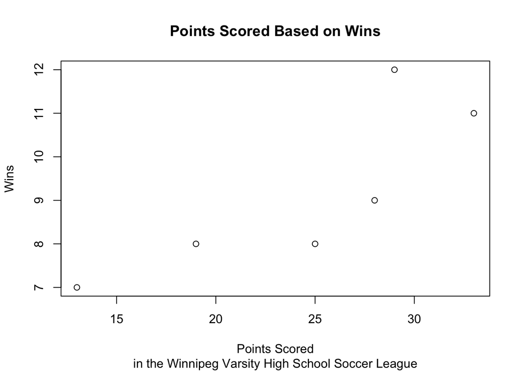

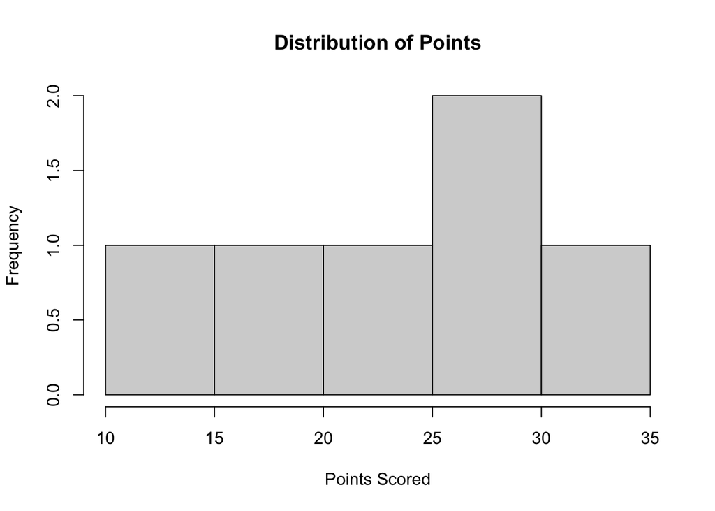

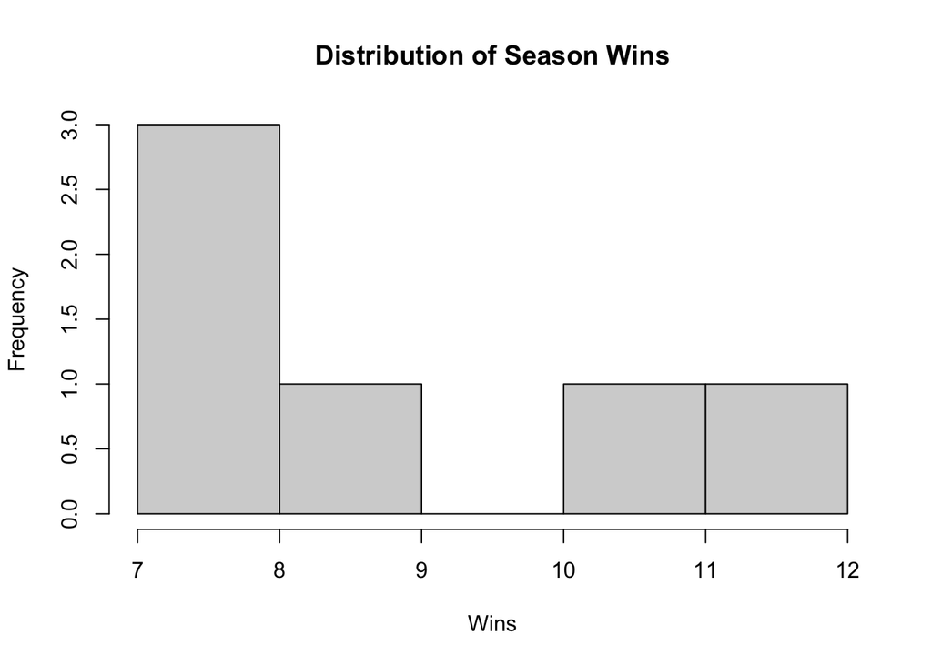

From the scatterplot, we can see that the number of wins increases based on the number of points scored. Based on the histograms, the distribution of number of points scored looks fairly uniform while the distribution of the number of wins is right-skewed.

## Numerical Summary

Now that we know the shapes, we can examine some numerical summaries which have been calculated in R and then re-summarized below the R calculations.

```r
# Means
mean(win)
```

```
## [1] 9.166667
```

```r
mean(point)
```

```
## [1] 24.5
```

```r
# Standard Deviations
sd(win)
```

```
## [1] 1.94079
```

```r
sd(point)
```

```
## [1] 7.314369
```

```r
# Correlation and Coefficient of Determination
cor(win,point)
```

```
## [1] 0.8241958
```

```r
cor(win,point)^2
```

```
## [1] 0.6792987
```

```r
# Max and Minimum Values
max(win)
```

```
## [1] 12
```

```r
min(win)
```

```
## [1] 7
```

```r
max(point)
```

```
## [1] 33
```

```r
min(point)
```

```
## [1] 13
```

We can summarize the stats in the following table:

[output not shown]

We also have that the correlation, $r$, is 0.8242 and the coefficient of determination, $r^2$, is 0.6793.